# Hierarchical Assignment

### Surbhi Khandelwal

The dataset Cereals.csv includes nutritional information, store display, and consumer ratings for 77 breakfast cereals.

Loading and installing all the required packages.

```r
library(tidyverse)  # data manipulation
library(factoextra) # clustering algorithms & visualization
library(arsenal)
library(ISLR)
library(tidyr)
library(caret)
library(dplyr)
library(flexclust)
library(ggplot2)
library(esquisse)
library(hrbrthemes)
library(GGally)
library(dummies)
library(viridis)
library(cluster)
library(geosphere)
library(raster)
library(gmodels)
```

Loading the data set.

```r
rm(list = ls(all=T))

Cerealdata <- read.csv("C:\\Users\\akash\\Desktop\\Kent - !st Sem\\RPractice\\ML\\Cereals.csv")
```

### Data Exploration

Before we answer any questions, let’s look at the data and try to understand it.

```r
#Studying the structure of the data
str(Cerealdata)
```

```
## 'data.frame':    77 obs. of  16 variables:
##  $ name    : chr  "100%_Bran" "100%_Natural_Bran" "All-Bran" "All-Bran_with_Extra_Fiber" ...
##  $ mfr     : chr  "N" "Q" "K" "K" ...
##  $ type    : chr  "C" "C" "C" "C" ...
##  $ calories: int  70 120 70 50 110 110 110 130 90 90 ...
##  $ protein : int  4 3 4 4 2 2 2 3 2 3 ...
##  $ fat     : int  1 5 1 0 2 2 0 2 1 0 ...
##  $ sodium  : int  130 15 260 140 200 180 125 210 200 210 ...
##  $ fiber   : num  10 2 9 14 1 1.5 1 2 4 5 ...
##  $ carbo   : num  5 8 7 8 14 10.5 11 18 15 13 ...
##  $ sugars  : int  6 8 5 0 8 10 14 8 6 5 ...
##  $ potass  : int  280 135 320 330 NA 70 30 100 125 190 ...
##  $ vitamins: int  25 0 25 25 25 25 25 25 25 25 ...
##  $ shelf   : int  3 3 3 3 3 1 2 3 1 3 ...
##  $ weight  : num  1 1 1 1 1 1 1 1.33 1 1 ...
##  $ cups    : num  0.33 1 0.33 0.5 0.75 0.75 1 0.75 0.67 0.67 ...
##  $ rating  : num  68.4 34 59.4 93.7 34.4 ...
```

```r
#Look at the head of the data
head(Cerealdata)
```

|  | name | mfr | type | calories | protein | fat | sodium | fiber | carbo | sugars | potass | vitamins | shelf | weight | cups | rating |
| --- | --- | --- | --- | --- | --- | --- | --- | --- | --- | --- | --- | --- | --- | --- | --- | --- |
| 1 | 100%_Bran | N | C | 70 | 4 | 1 | 130 | 10.0 | 5.0 | 6 | 280 | 25 | 3 | 1 | 0.33 | 68.40297 |
| 2 | 100%_Natural_Bran | Q | C | 120 | 3 | 5 | 15 | 2.0 | 8.0 | 8 | 135 | 0 | 3 | 1 | 1.00 | 33.98368 |
| 3 | All-Bran | K | C | 70 | 4 | 1 | 260 | 9.0 | 7.0 | 5 | 320 | 25 | 3 | 1 | 0.33 | 59.42551 |
| 4 | All-Bran_with_Extra_Fiber | K | C | 50 | 4 | 0 | 140 | 14.0 | 8.0 | 0 | 330 | 25 | 3 | 1 | 0.50 | 93.70491 |
| 5 | Almond_Delight | R | C | 110 | 2 | 2 | 200 | 1.0 | 14.0 | 8 | NA | 25 | 3 | 1 | 0.75 | 34.38484 |
| 6 | Apple_Cinnamon_Cheerios | G | C | 110 | 2 | 2 | 180 | 1.5 | 10.5 | 10 | 70 | 25 | 1 | 1 | 0.75 | 29.50954 |

```r
#Look at the summary of the data set
summary(Cerealdata)
```

```
##      name               mfr                type              calories
##  Length:77          Length:77          Length:77          Min.   : 50.0
##  Class :character   Class :character   Class :character   1st Qu.:100.0
##  Mode  :character   Mode  :character   Mode  :character   Median :110.0
##                                                           Mean   :106.9
##                                                           3rd Qu.:110.0
##                                                           Max.   :160.0
##
##     protein           fat            sodium          fiber
##  Min.   :1.000   Min.   :0.000   Min.   :  0.0   Min.   : 0.000
##  1st Qu.:2.000   1st Qu.:0.000   1st Qu.:130.0   1st Qu.: 1.000
##  Median :3.000   Median :1.000   Median :180.0   Median : 2.000
##  Mean   :2.545   Mean   :1.013   Mean   :159.7   Mean   : 2.152
##  3rd Qu.:3.000   3rd Qu.:2.000   3rd Qu.:210.0   3rd Qu.: 3.000
##  Max.   :6.000   Max.   :5.000   Max.   :320.0   Max.   :14.000
##
##      carbo          sugars           potass          vitamins
##  Min.   : 5.0   Min.   : 0.000   Min.   : 15.00   Min.   :  0.00
##  1st Qu.:12.0   1st Qu.: 3.000   1st Qu.: 42.50   1st Qu.: 25.00
##  Median :14.5   Median : 7.000   Median : 90.00   Median : 25.00
##  Mean   :14.8   Mean   : 7.026   Mean   : 98.67   Mean   : 28.25
##  3rd Qu.:17.0   3rd Qu.:11.000   3rd Qu.:120.00   3rd Qu.: 25.00
##  Max.   :23.0   Max.   :15.000   Max.   :330.00   Max.   :100.00
##  NA's   :1      NA's   :1        NA's   :2
##      shelf           weight          cups           rating
##  Min.   :1.000   Min.   :0.50   Min.   :0.250   Min.   :18.04
##  1st Qu.:1.000   1st Qu.:1.00   1st Qu.:0.670   1st Qu.:33.17
##  Median :2.000   Median :1.00   Median :0.750   Median :40.40
##  Mean   :2.208   Mean   :1.03   Mean   :0.821   Mean   :42.67
##  3rd Qu.:3.000   3rd Qu.:1.00   3rd Qu.:1.000   3rd Qu.:50.83
##  Max.   :3.000   Max.   :1.50   Max.   :1.500   Max.   :93.70
##
```

### Data Preperation

Attribute ‘shelf’ is a categorical variable. Lets convert it into a factor.

```r
Cerealdata$shelf = as.factor(as.character(Cerealdata$shelf))
```

Convert the names of the breakfast cereals to the row names, as this will later help us in visualising the clusters

```r
rownames(Cerealdata) <- Cerealdata$name

#Drop the name column as it is now just redundant information
Cerealdata$name = NULL
```

### Scaling the Data

I am scaling the entire dataset without dividing it into train and test because it’s an unsupervised model. Since we won’t be able to automatically calculate the accuracy/effectiveness of your model. We can only calculate the distance value and understand how our model is doing.

To do this, let’s first divide the data into categorical and continous. Categorical Variables - mfr, type

Continous Measurements - calories, protein, fat, sodium, fiber, carbo, sugars, potass, vitamins, shelf, weight, cups, rating

Now let’s create the dataset with just the continous measurements.

```r
Cerealdata_cont <- dplyr::select(Cerealdata, -mfr, -type)
```

Convert the categorical variable Shelf to dummy variables (converting to numeric attributes by using dummy)

```r
#Make a copy of the dataframe for later use (mixed attributes)
shelfDummies = data.frame(dummy(Cerealdata_cont$shelf))
#Name the new attributes appropriately
names(shelfDummies) = c("Shelf1","Shelf2","Shelf3")
head(shelfDummies)
```

|  | Shelf1 | Shelf2 | Shelf3 |
| --- | --- | --- | --- |
| 1 | 0 | 0 | 1 |
| 2 | 0 | 0 | 1 |
| 3 | 0 | 0 | 1 |
| 4 | 0 | 0 | 1 |
| 5 | 0 | 0 | 1 |
| 6 | 1 | 0 | 0 |

Remove the original attribute ‘shelf’ and add the newly created dummy variables

```r
Cerealdata_cont$shelf = NULL
Cerealdata_cont = data.frame(cbind(Cerealdata_cont, shelfDummies))

#check the dataframe using head()
head(Cerealdata_cont)
```

|  | calories | protein | fat | sodium | fiber | carbo | sugars | potass | vitamins | weight | cups | rating | Shelf1 | Shelf2 | Shelf3 |
| --- | --- | --- | --- | --- | --- | --- | --- | --- | --- | --- | --- | --- | --- | --- | --- |
| 100%_Bran | 70 | 4 | 1 | 130 | 10.0 | 5.0 | 6 | 280 | 25 | 1 | 0.33 | 68.40297 | 0 | 0 | 1 |
| 100%_Natural_Bran | 120 | 3 | 5 | 15 | 2.0 | 8.0 | 8 | 135 | 0 | 1 | 1.00 | 33.98368 | 0 | 0 | 1 |
| All-Bran | 70 | 4 | 1 | 260 | 9.0 | 7.0 | 5 | 320 | 25 | 1 | 0.33 | 59.42551 | 0 | 0 | 1 |
| All-Bran_with_Extra_Fiber | 50 | 4 | 0 | 140 | 14.0 | 8.0 | 0 | 330 | 25 | 1 | 0.50 | 93.70491 | 0 | 0 | 1 |
| Almond_Delight | 110 | 2 | 2 | 200 | 1.0 | 14.0 | 8 | NA | 25 | 1 | 0.75 | 34.38484 | 0 | 0 | 1 |
| Apple_Cinnamon_Cheerios | 110 | 2 | 2 | 180 | 1.5 | 10.5 | 10 | 70 | 25 | 1 | 0.75 | 29.50954 | 1 | 0 | 0 |

### Scaling the data frame (z-score)

```r
Cerealdata_cont <- scale(Cerealdata_cont)

#Let's look at the head of the scaled data
head(Cerealdata_cont)
```

```
##                             calories    protein         fat     sodium
## 100%_Bran                 -1.8929836  1.3286071 -0.01290349 -0.3539844
## 100%_Natural_Bran          0.6732089  0.4151897  3.96137277 -1.7257708
## All-Bran                  -1.8929836  1.3286071 -0.01290349  1.1967306
## All-Bran_with_Extra_Fiber -2.9194605  1.3286071 -1.00647256 -0.2346986
## Almond_Delight             0.1599704 -0.4982277  0.98066557  0.4810160
## Apple_Cinnamon_Cheerios    0.1599704 -0.4982277  0.98066557  0.2424445
##                                 fiber      carbo     sugars     potass
## 100%_Bran                  3.29284661 -2.5087829 -0.2343906  2.5753685
## 100%_Natural_Bran         -0.06375361 -1.7409943  0.2223705  0.5160205
## All-Bran                   2.87327158 -1.9969238 -0.4627711  3.1434645
## All-Bran_with_Extra_Fiber  4.97114672 -1.7409943 -1.6046739  3.2854885
## Almond_Delight            -0.48332864 -0.2054171  0.2223705         NA
## Apple_Cinnamon_Cheerios   -0.27354112 -1.1011705  0.6791317 -0.4071355
##                             vitamins     weight       cups     rating
## 100%_Bran                 -0.1453172 -0.1967771 -2.1100340  1.8321876
## 100%_Natural_Bran         -1.2642598 -0.1967771  0.7690100 -0.6180571
## All-Bran                  -0.1453172 -0.1967771 -2.1100340  1.1930986
## All-Bran_with_Extra_Fiber -0.1453172 -0.1967771 -1.3795303  3.6333849
## Almond_Delight            -0.1453172 -0.1967771 -0.3052601 -0.5894990
## Apple_Cinnamon_Cheerios   -0.1453172 -0.1967771 -0.3052601 -0.9365625
##                               Shelf1    Shelf2    Shelf3
## 100%_Bran                 -0.5884899 -0.608383  1.060235
## 100%_Natural_Bran         -0.5884899 -0.608383  1.060235
## All-Bran                  -0.5884899 -0.608383  1.060235
## All-Bran_with_Extra_Fiber -0.5884899 -0.608383  1.060235
## Almond_Delight            -0.5884899 -0.608383  1.060235
## Apple_Cinnamon_Cheerios    1.6771962 -0.608383 -0.930938
```

### Remove all records with missing measurements from the dataset.

```r
#Let's look at the percentage of missing values for each variable in the dataset.

navalues<- colMeans(is.na(Cerealdata_cont))*100
as.data.frame(navalues)
```

|  | navalues |
| --- | --- |
| calories | 0.000000 |
| protein | 0.000000 |
| fat | 0.000000 |
| sodium | 0.000000 |
| fiber | 0.000000 |
| carbo | 1.298701 |
| sugars | 1.298701 |
| potass | 2.597403 |
| vitamins | 0.000000 |
| weight | 0.000000 |

[output cut: 5 more lines]

We notice that there are a few columns with missing data. So Let’s remove the missing data.

```r
#Removing all the null values.

Cerealdata_cont <- na.omit(Cerealdata_cont)
```

# Part 1: Apply hierarchical clustering to the data using Euclidean distance to the normalized measurements. Use Agnes to compare the clustering from single linkage, complete linkage, average linkage, and Ward. Choose the best method.

Getting the distance and plotting it out.

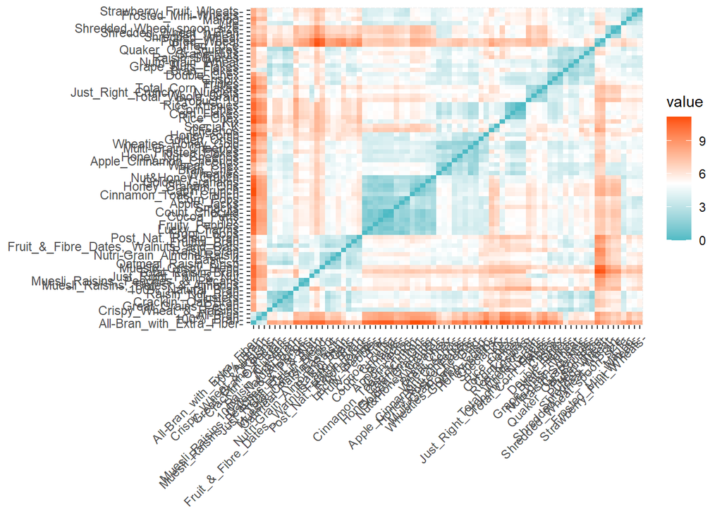

```r
distance <- get_dist(Cerealdata_cont)
fviz_dist(distance, gradient = list(low = "#00AFBB", mid = "white", high = "#FC4E07"))
```

### Hierarchical Clustering

Get agglomerative coefficient for each linkage method and compare all of them together.

```r
set.seed(123)
m <- c( "average", "single", "complete", "ward")
names(m) <- c( "average", "single", "complete", "ward")

# function to compute coefficient
ac <- function(x) {
  agnes(Cerealdata_cont, method = x)$ac
}

# get agglomerative coefficient for each linkage method
purrr::map_dbl(m, ac)
```

```
##   average    single  complete      ward
## 0.7747319 0.6254518 0.8358330 0.9049837
```

Looking at the agglomerative coefficient for all the linkage methods, we see that ward linkage is the highest.

### Hierarchical Clustering procedure using ward.D2

Let’s now perform hierarchical clustering using the hclust() function, for which we’ll first need to calculate the distance measures

```r
set.seed(123)
dist <- dist(Cerealdata_cont, method = "euclidean")
hc_fit <- hclust(dist, method = "ward.D2")
```

We can display the dendrogram for hierarchical clustering, using the plot() function

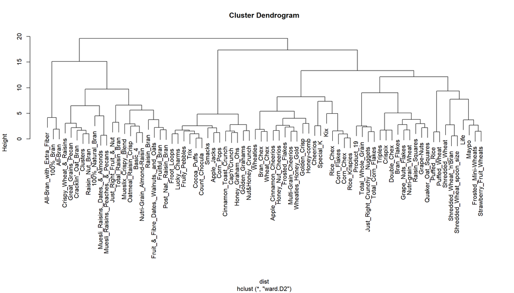

```r
plot(hc_fit)
```

### Part 3: How many clusters would you choose?

Looking at the plot, it looks like 6 could be a good value for no. of clusters. It looks like cutting the clusters at height 12 would be a good idea.

Cut the tree to 6 clusters, using the cutree() function

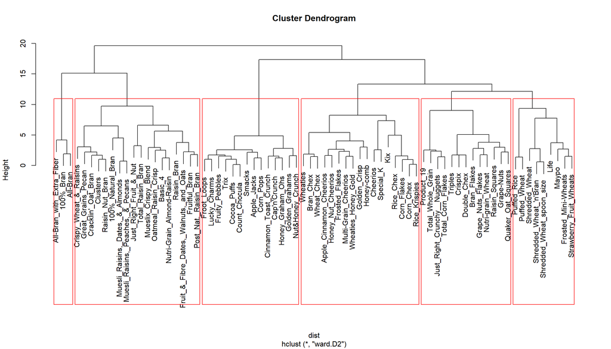

```r
plot(hc_fit)

#Plot clusters being surrounded by a border, using the rect.hclust() function
rect.hclust(hc_fit, k = 6, border = "red")
```

```r
points_hc <- cutree(hc_fit, k = 6)

#Store the clusters in a data frame along with the cereals data
cereals_clusts_hc <- cbind(points_hc, Cerealdata_cont)

#Have a look at the head of the new data frame
colnames(cereals_clusts_hc)[1] <- "cluster_hc"
head(cereals_clusts_hc)
```

```
##                           cluster_hc   calories    protein         fat
## 100%_Bran                          1 -1.8929836  1.3286071 -0.01290349
## 100%_Natural_Bran                  2  0.6732089  0.4151897  3.96137277
## All-Bran                           1 -1.8929836  1.3286071 -0.01290349
## All-Bran_with_Extra_Fiber          1 -2.9194605  1.3286071 -1.00647256
## Apple_Cinnamon_Cheerios            3  0.1599704 -0.4982277  0.98066557
## Apple_Jacks                        4  0.1599704 -0.4982277 -1.00647256
##                               sodium       fiber      carbo     sugars
## 100%_Bran                 -0.3539844  3.29284661 -2.5087829 -0.2343906
## 100%_Natural_Bran         -1.7257708 -0.06375361 -1.7409943  0.2223705
## All-Bran                   1.1967306  2.87327158 -1.9969238 -0.4627711
## All-Bran_with_Extra_Fiber -0.2346986  4.97114672 -1.7409943 -1.6046739
## Apple_Cinnamon_Cheerios    0.2424445 -0.27354112 -1.1011705  0.6791317
## Apple_Jacks               -0.4136273 -0.48332864 -0.9732057  1.5926539
##                               potass   vitamins     weight       cups
## 100%_Bran                  2.5753685 -0.1453172 -0.1967771 -2.1100340
## 100%_Natural_Bran          0.5160205 -1.2642598 -0.1967771  0.7690100
## All-Bran                   3.1434645 -0.1453172 -0.1967771 -2.1100340
## All-Bran_with_Extra_Fiber  3.2854885 -0.1453172 -0.1967771 -1.3795303
## Apple_Cinnamon_Cheerios   -0.4071355 -0.1453172 -0.1967771 -0.3052601
## Apple_Jacks               -0.9752315 -0.1453172 -0.1967771  0.7690100
##                               rating     Shelf1    Shelf2    Shelf3
## 100%_Bran                  1.8321876 -0.5884899 -0.608383  1.060235
## 100%_Natural_Bran         -0.6180571 -0.5884899 -0.608383  1.060235
## All-Bran                   1.1930986 -0.5884899 -0.608383  1.060235
## All-Bran_with_Extra_Fiber  3.6333849 -0.5884899 -0.608383  1.060235
## Apple_Cinnamon_Cheerios   -0.9365625  1.6771962 -0.608383 -0.930938
## Apple_Jacks               -0.6756899 -0.5884899  1.622355 -0.930938
```

### Part 2: Comment on differences between hierarchical Clustering and K-means.

Let’s run k-means algorithm and see what we get.

```r
set.seed(123)
k3 <- kmeans(Cerealdata_cont, centers = 6, nstart = 25) # k = 3, number of restarts = 25

# Visualize the output

k3$centers # output the centers
```

```
##      calories     protein        fat      sodium       fiber      carbo
## 1 -0.06457140 -0.04151897 -0.3854919  0.72331522 -0.35221144  0.4024155
## 2 -1.26569205 -0.09226438 -0.8960760 -1.88481846 -0.01713416  0.1358223
## 3  0.25620266 -0.89784778  0.1733907  0.14925245 -0.71933959 -0.4933378
## 4 -0.07690887  0.13413822 -0.4714738  0.43054894 -0.09602861  0.7592403
## 5 -2.23514255  1.32860712 -0.3440932  0.20268253  3.71242164 -2.0822337
## 6  0.97511394  0.46892016  1.0391108 -0.04875316  0.47922584 -0.2806905
##       sugars     potass    vitamins      weight        cups     rating
## 1 -0.2201168 -0.4737092 -0.14531722 -0.19677711  0.48164274 -0.1160434
## 2 -1.0717860 -0.1151972 -0.76695199 -1.06069766  0.11967338  1.4488698
## 3  0.8932384 -0.7888250 -0.14531722 -0.19677711  0.39032978 -0.9991919
## 4 -0.6208808 -0.2214118  1.14577038 -0.04341843 -0.04082441  0.2387116
## 5 -0.7672786  3.0014405 -0.14531722 -0.19677711 -1.86653275  2.2195570
## 6  0.6253951  0.8794349 -0.01367691  1.03460286 -0.51253109 -0.3827249
##       Shelf1     Shelf2     Shelf3
## 1  1.6771962 -0.6083830 -0.9309380
## 2  0.1667388  0.1351962 -0.2672137
## 3 -0.5884899  1.6223547 -0.9309380
## 4 -0.5884899 -0.6083830  1.0602349
## 5 -0.5884899 -0.6083830  1.0602349
## 6 -0.5884899 -0.4771631  0.9431071
```

```r
k3$size # Number of Universities in each cluster
```

```
## [1] 16  9 16 13  3 17
```

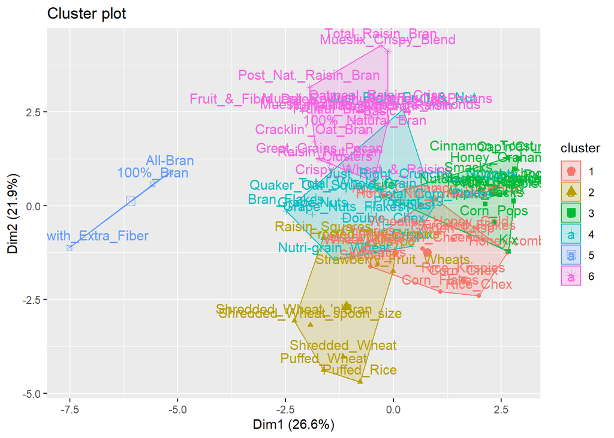

```r
fviz_cluster(k3, data = Cerealdata_cont) # Visualize the output
```

In hierarchical clustering, looking at the dendograms, it gives us a much clear way of understanding how the clusters are linked and how the data points are related. But kmeans does not provide that kind of understanding.

Hierarchical clustering (AGNES) starts with all the data points assigned to a cluster of their own. Then two nearest clusters are merged into the same cluster. In the end, this algorithm terminates when there is only a single cluster left.

The decision of the no. of clusters that can best depict different groups can be chosen by observing the dendrogram. The best choice of the no. of clusters is the no. of vertical lines in the dendrogram cut by a horizontal line that can transverse the maximum distance vertically without intersecting a cluster.

### Part 4: Comment on the structure of the clusters and on their stability. Hint: To check stability, partition the data and see how well clusters formed based on one part apply to the other part.

Partition the data.

```r
#Divide the data into 60% training to cross verify.

Cerealdata_cont1 <- as.data.frame(Cerealdata_cont)

set.seed(123)
#Divide data into 60% training.
Index_Train<-createDataPartition(Cerealdata_cont1$fat, p=0.6, list=FALSE)
Traindata <- Cerealdata_cont1[Index_Train, ]
```

Let’s assign cluster values to the train data using hierarchical clustering.

```r
set.seed(123)
dist_train <- dist(Traindata, method = "euclidean")
hc_fit_train <- hclust(dist_train, method = "ward.D2")
```

Let’s assign the cluster values to these data sets with number of clusters as 6.

```r
points_hc_train <- cutree(hc_fit_train, k = 6)

# Store the clusters in a data frame along with the cereals data
Traindata_clusts_hc <- cbind(points_hc_train, Traindata)

# Have a look at the head of the new data frame
colnames(Traindata_clusts_hc)[1] <- "cluster_hc"
head(Traindata_clusts_hc)
```

|  | cluster_hc | calories | protein | fat | sodium | fiber | carbo | sugars | potass | vitamins | weight | cups | rating | Shelf1 | Shelf2 | Shelf3 |
| --- | --- | --- | --- | --- | --- | --- | --- | --- | --- | --- | --- | --- | --- | --- | --- | --- |
| All-Bran_with_Extra_Fiber | 1 | -2.9194605 | 1.3286071 | -1.00647256 | -0.2346986 | 4.97114672 | -1.74099432 | -1.604673946 | 3.28548848 | -0.1453172 | -0.1967771 | -1.3795303 | 3.6333849 | -0.5884899 | -0.608383 | 1.060235 |
| Apple_Jacks | 2 | 0.1599704 | -0.4982277 | -1.00647256 | -0.4136273 | -0.48332864 | -0.97320572 | 1.592653916 | -0.97523145 | -0.1453172 | -0.1967771 | 0.7690100 | -0.6756899 | -0.5884899 | 1.622355 | -0.930938 |
| Basic_4 | 3 | 1.1864474 | 0.4151897 | 0.98066557 | 0.6003018 | -0.06375361 | 0.81830100 | 0.222370547 | 0.01893653 | -0.1453172 | 1.9962520 | -0.3052601 | -0.4005857 | -0.5884899 | -0.608383 | 1.060235 |
| Bran_Chex | 4 | -0.8665066 | -0.4982277 | -0.01290349 | 0.4810160 | 0.77539645 | 0.05051241 | -0.234390576 | 0.37399653 | -0.1453172 | -0.1967771 | -0.6490266 | 0.4594871 | 1.6771962 | -0.608383 | -0.930938 |
| Cheerios | 4 | 0.1599704 | 3.1554419 | 0.98066557 | 1.5545879 | -0.06375361 | 0.56237147 | -1.376293384 | 0.08994853 | -0.1453172 | -0.1967771 | 1.8432802 | 0.5765735 | 1.6771962 | -0.608383 | -0.930938 |
| Clusters | 3 | 0.1599704 | 0.4151897 | 0.98066557 | -0.2346986 | -0.06375361 | -0.46134666 | -0.006010015 | 0.08994853 | -0.1453172 | -0.1967771 | -1.3795303 | -0.1612765 | -0.5884899 | -0.608383 | 1.060235 |

```r
Traindata_clust <- data.frame(Traindata_clusts_hc)
```

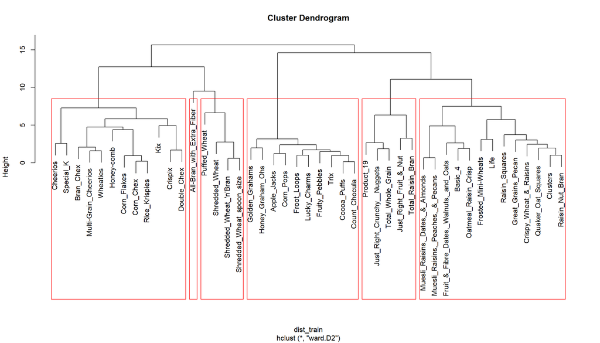

```r
plot(hc_fit_train)

#Plot clusters being surrounded by a border, using the rect.hclust() function
rect.hclust(hc_fit_train, k = 6, border = "red")
```

```r
cereals_clust <- data.frame(cereals_clusts_hc)
```

By comparing the 2 dendograms, we can see that:

```r
# Now take means per group, this will give us the centroid values for all the clusters.
centroids <- cereals_clust %>%
        group_by(cluster_hc) %>%
        summarise_all(funs(mean))
centroids
```

| cluster_hc | calories | protein | fat | sodium | fiber | carbo | sugars | potass | vitamins | weight | cups | rating | Shelf1 | Shelf2 | Shelf3 |
| --- | --- | --- | --- | --- | --- | --- | --- | --- | --- | --- | --- | --- | --- | --- | --- |
| 1 | -2.23514255 | 1.32860712 | -0.3440932 | 0.20268253 | 3.71242164 | -2.08223369 | -0.7672786 | 3.0014405 | -0.1453172 | -0.1967771 | -1.8665328 | 2.2195570 | -0.5884899 | -0.6083830 | 1.0602349 |
| 2 | 1.01536794 | 0.46593514 | 0.9806656 | -0.03920250 | 0.44906031 | -0.19119882 | 0.6156926 | 0.8276843 | 0.1655002 | 1.0769519 | -0.5010160 | -0.3859598 | -0.5884899 | -0.4844531 | 0.9496142 |
| 3 | -0.05136306 | -0.06838419 | -0.3635749 | 0.75116319 | -0.38460510 | 0.47204340 | -0.2612589 | -0.4948562 | -0.1453172 | -0.1967771 | 0.6249314 | -0.1235579 | 1.5439205 | -0.4771631 | -0.9309380 |
| 4 | 0.30661001 | -1.08542457 | 0.1290349 | 0.09333724 | -0.75305544 | -0.62587278 | 1.1032670 | -0.8382797 | -0.1453172 | -0.1967771 | 0.2840538 | -1.1380578 | -0.5884899 | 1.6223547 | -0.9309380 |
| 5 | -0.27430829 | 0.06387534 | -0.5479022 | 0.27455986 | -0.09602861 | 0.66080591 | -0.6735840 | -0.2050244 | 0.8875529 | -0.1967771 | -0.1234606 | 0.3419981 | -0.5884899 | -0.6083830 | 1.0602349 |
| 6 | -1.20866555 | 0.11071726 | -0.6752829 | -1.68600885 | -0.01713416 | 0.05051241 | -1.0717860 | -0.1388679 | -0.7669520 | -1.0606977 | 0.2008405 | 1.3697318 | 0.1667388 | 0.3830560 | -0.4884551 |

```r
centroids$cluster_hc <- as.factor(centroids$cluster_hc)

centroids
```

| cluster_hc | calories | protein | fat | sodium | fiber | carbo | sugars | potass | vitamins | weight | cups | rating | Shelf1 | Shelf2 | Shelf3 |
| --- | --- | --- | --- | --- | --- | --- | --- | --- | --- | --- | --- | --- | --- | --- | --- |
| 1 | -2.23514255 | 1.32860712 | -0.3440932 | 0.20268253 | 3.71242164 | -2.08223369 | -0.7672786 | 3.0014405 | -0.1453172 | -0.1967771 | -1.8665328 | 2.2195570 | -0.5884899 | -0.6083830 | 1.0602349 |
| 2 | 1.01536794 | 0.46593514 | 0.9806656 | -0.03920250 | 0.44906031 | -0.19119882 | 0.6156926 | 0.8276843 | 0.1655002 | 1.0769519 | -0.5010160 | -0.3859598 | -0.5884899 | -0.4844531 | 0.9496142 |
| 3 | -0.05136306 | -0.06838419 | -0.3635749 | 0.75116319 | -0.38460510 | 0.47204340 | -0.2612589 | -0.4948562 | -0.1453172 | -0.1967771 | 0.6249314 | -0.1235579 | 1.5439205 | -0.4771631 | -0.9309380 |
| 4 | 0.30661001 | -1.08542457 | 0.1290349 | 0.09333724 | -0.75305544 | -0.62587278 | 1.1032670 | -0.8382797 | -0.1453172 | -0.1967771 | 0.2840538 | -1.1380578 | -0.5884899 | 1.6223547 | -0.9309380 |
| 5 | -0.27430829 | 0.06387534 | -0.5479022 | 0.27455986 | -0.09602861 | 0.66080591 | -0.6735840 | -0.2050244 | 0.8875529 | -0.1967771 | -0.1234606 | 0.3419981 | -0.5884899 | -0.6083830 | 1.0602349 |
| 6 | -1.20866555 | 0.11071726 | -0.6752829 | -1.68600885 | -0.01713416 | 0.05051241 | -1.0717860 | -0.1388679 | -0.7669520 | -1.0606977 | 0.2008405 | 1.3697318 | 0.1667388 | 0.3830560 | -0.4884551 |

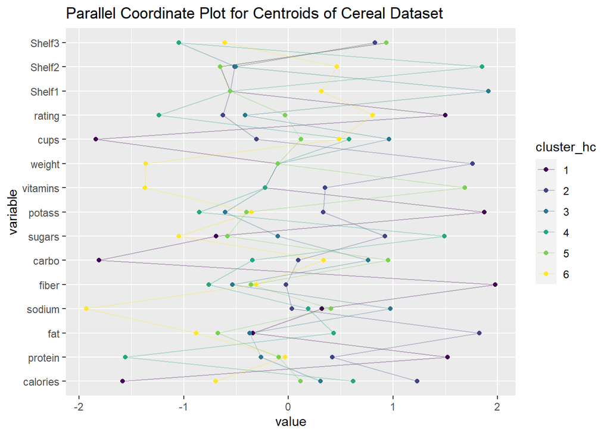

```r
ggparcoord(centroids,
    columns = 2:16, groupColumn = 1,
    showPoints = TRUE,
    title = "Parallel Coordinate Plot for Centroids of Cereal Dataset",
    alphaLines = 0.3
    ) +
  scale_color_viridis(discrete=TRUE)+
  coord_flip()
```

### Quality of Clusters Created

- Shiloutte width
  - The silhouette width/value is a measure of how similar an object is to its own cluster (cohesion) compared to other clusters (separation) [i.e., intra-cluster cohesion and inter-cluster separation]
  - Ranges from -1 to +1
  - Values closer to 1 means higher quality of the cluster created

```r
dist = daisy(x = Cerealdata_cont, metric = "euclidean")
```

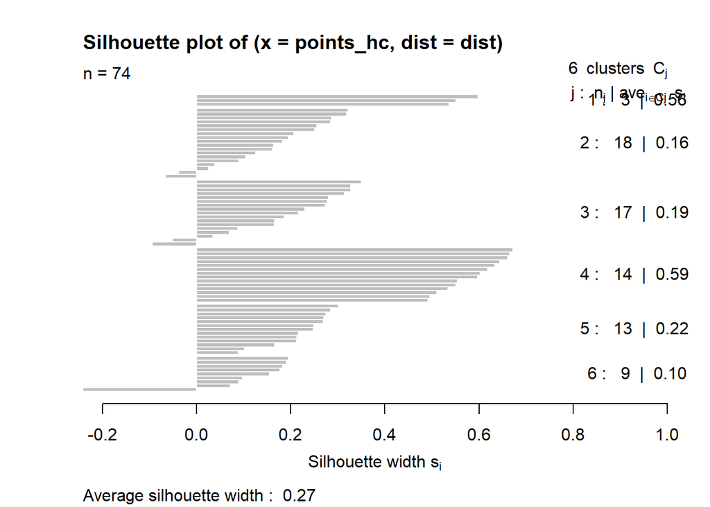

```r
sil_value = silhouette(points_hc, dist = dist)
plot(sil_value)
```

### Part 5: How do you compare hierarchical clustering and k-means? What are they main advantages of hierarchical clustering compared to k-means?

There are quite a few differences between where to use K means and Hierarchical clustering. Majorly being on the basis of Scalability and Flexibility.

Hierarchical is Flexible but can not be used on large data. K means is scalable but cannot use for flexible data.

In Hierarchical Clustering, for large data set, you will not be able to clearly visualize the final output. You can still use this to check at which point the item was split into different categories. On the other hand, the K means is only applicable on only numeric data.